# The Master’s University and Seminary (Santa Clarita, CA)

### Diversity among the students

|  | Undergrad (count) | Grad student (count) | Undergrads (percent) | Grad students (percent) |
| --- | --- | --- | --- | --- |
| Grand total men | 446 | 128 | 49.4% | 85.3% |
| Grand total women | 456 | 22 | 50.6% | 14.7% |
| American Indian or Alaska Native men | 1 | 0 | 0.1% | 0% |
| American Indian or Alaska Native women | 2 | 0 | 0.2% | 0% |
| Asian men | 22 | 14 | 2.4% | 9.3% |
| Asian women | 6 | 2 | 0.7% | 1.3% |
| Black or African American men | 10 | 6 | 1.1% | 4% |
| Black or African American women | 10 | 1 | 1.1% | 0.7% |
| Hispanic men | 43 | 28 | 4.8% | 18.7% |
| Hispanic women | 36 | 5 | 4% | 3.3% |
| Native Hawaiian or Other Pacific Islander men | 1 | 0 | 0.1% | 0% |
| Native Hawaiian or Other Pacific Islander women | 2 | 0 | 0.2% | 0% |
| White men | 300 | 57 | 33.3% | 38% |
| White women | 313 | 10 | 34.7% | 6.7% |
| Two or more races men | 43 | 3 | 4.8% | 2% |
| Two or more races women | 46 | 1 | 5.1% | 0.7% |
| Race/ethnicity unknown men | 19 | 8 | 2.1% | 5.3% |
| Race/ethnicity unknown women | 34 | 1 | 3.8% | 0.7% |
| Nonresident alien men | 7 | 12 | 0.8% | 8% |
| Nonresident alien women | 7 | 2 | 0.8% | 1.3% |

### US student origins

First time degree seeking undergrads

**There are no available data on states of origin**

### Library resources

[output not shown]

## Figures

### Student to faculty ratio compared to similar institutions:

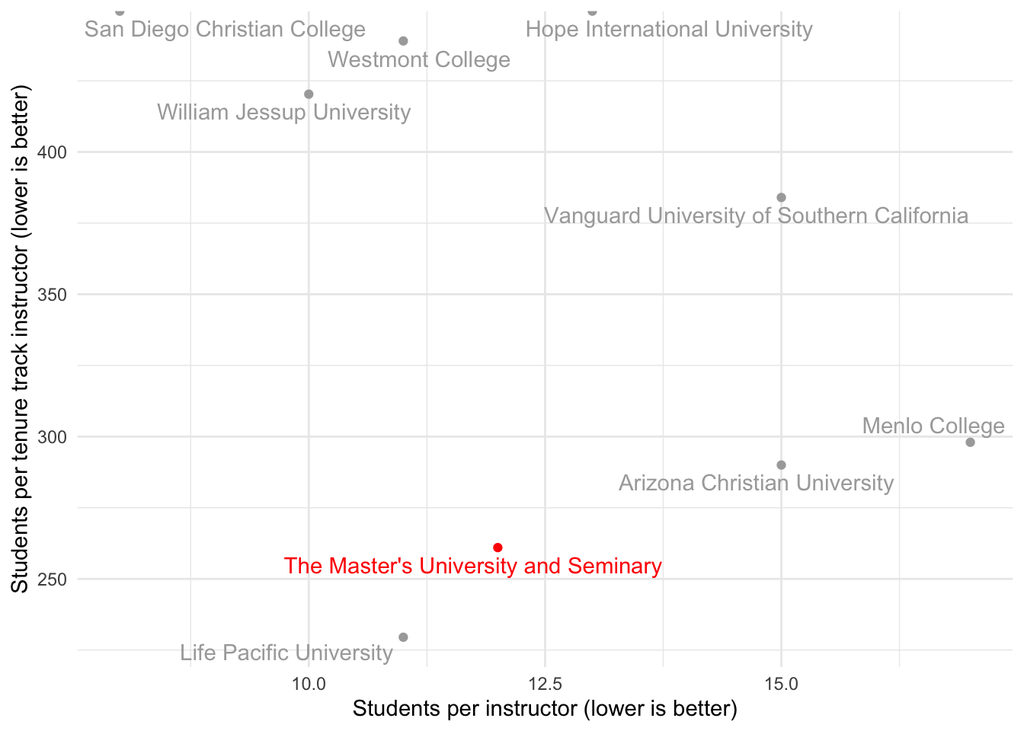